# Vincent Eung - Hugo Grandjean - BIA 1 - Promo 2024

```python
import pandas as pd
import numpy as np
from sklearn.linear_model import LinearRegression
import matplotlib.pyplot as plt
from sklearn.model_selection import train_test_split
from sklearn.metrics import mean_squared_error
from sklearn.svm import SVC
from sklearn.metrics import accuracy_score, classification_report
from sklearn.neighbors import KNeighborsClassifier
from sklearn.model_selection import GridSearchCV
import seaborn as sns
from sklearn.inspection import permutation_importance
```

```python
df = pd.read_csv('wine.csv')
df
```

|  | fixed acidity | volatile acidity | citric acid | residual sugar | chlorides | free sulfur dioxide | total sulfur dioxide | density | pH | sulphates | alcohol | quality |
| --- | --- | --- | --- | --- | --- | --- | --- | --- | --- | --- | --- | --- |
| 0 | 7.0 | 0.27 | 0.36 | 20.7 | 0.045 | 45.0 | 170.0 | 1.00100 | 3.00 | 0.45 | 8.8 | 6 |
| 1 | 6.3 | 0.30 | 0.34 | 1.6 | 0.049 | 14.0 | 132.0 | 0.99400 | 3.30 | 0.49 | 9.5 | 6 |
| 2 | 8.1 | 0.28 | 0.40 | 6.9 | 0.050 | 30.0 | 97.0 | 0.99510 | 3.26 | 0.44 | 10.1 | 6 |
| 3 | 7.2 | 0.23 | 0.32 | 8.5 | 0.058 | 47.0 | 186.0 | 0.99560 | 3.19 | 0.40 | 9.9 | 6 |
| 4 | 7.2 | 0.23 | 0.32 | 8.5 | 0.058 | 47.0 | 186.0 | 0.99560 | 3.19 | 0.40 | 9.9 | 6 |
| ... | ... | ... | ... | ... | ... | ... | ... | ... | ... | ... | ... | ... |
| 4893 | 6.2 | 0.21 | 0.29 | 1.6 | 0.039 | 24.0 | 92.0 | 0.99114 | 3.27 | 0.50 | 11.2 | 6 |
| 4894 | 6.6 | 0.32 | 0.36 | 8.0 | 0.047 | 57.0 | 168.0 | 0.99490 | 3.15 | 0.46 | 9.6 | 5 |
| 4895 | 6.5 | 0.24 | 0.19 | 1.2 | 0.041 | 30.0 | 111.0 | 0.99254 | 2.99 | 0.46 | 9.4 | 6 |
| 4896 | 5.5 | 0.29 | 0.30 | 1.1 | 0.022 | 20.0 | 110.0 | 0.98869 | 3.34 | 0.38 | 12.8 | 7 |
| 4897 | 6.0 | 0.21 | 0.38 | 0.8 | 0.020 | 22.0 | 98.0 | 0.98941 | 3.26 | 0.32 | 11.8 | 6 |

4898 rows × 12 columns

```
Missing values for each column:
fixed acidity           0
volatile acidity        0
citric acid             0
residual sugar          0
chlorides               0
free sulfur dioxide     0
total sulfur dioxide    0
density                 0
pH                      0
sulphates               0
alcohol                 0
quality                 0
dtype: int64
<class 'pandas.core.frame.DataFrame'>
RangeIndex: 4898 entries, 0 to 4897
Data columns (total 12 columns):
 #   Column                Non-Null Count  Dtype
---  ------                --------------  -----
 0   fixed acidity         4898 non-null   float64
 1   volatile acidity      4898 non-null   float64
 2   citric acid           4898 non-null   float64
 3   residual sugar        4898 non-null   float64
 4   chlorides             4898 non-null   float64
 5   free sulfur dioxide   4898 non-null   float64
 6   total sulfur dioxide  4898 non-null   float64
 7   density               4898 non-null   float64
 8   pH                    4898 non-null   float64
 9   sulphates             4898 non-null   float64
 10  alcohol               4898 non-null   float64
 11  quality               4898 non-null   int64
dtypes: float64(11), int64(1)
memory usage: 459.3 KB
```

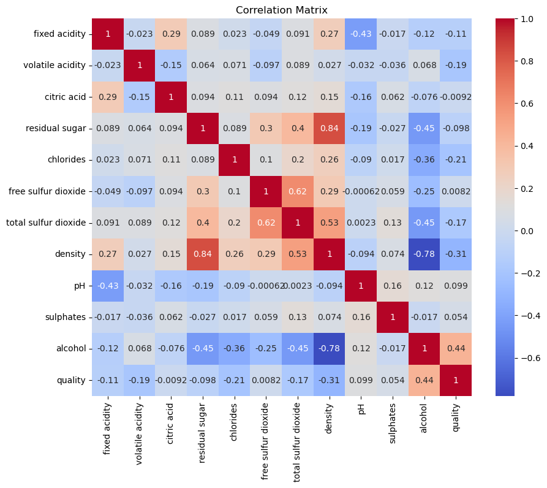

```python
# Calculate missing values for each column
missing_values = df.isnull().sum()

# Display the missing values
print("Missing values for each column:")
print(missing_values)

import seaborn as sns
import matplotlib.pyplot as plt

# Compute the correlation matrix
correlation = df.corr()

###############################################################################
# Display the first few rows of the dataset
df.head()

# Get information about the dataset
df.info()

# Statistical summary of the dataset
df.describe()
#############################################################################""
# Create a heatmap of the correlation matrix
plt.figure(figsize=(10, 8))
sns.heatmap(correlation, annot=True, cmap='coolwarm')
plt.title("Correlation Matrix")
plt.show()

########################################################################
import seaborn as sns
import matplotlib.pyplot as plt

# Compute the correlation matrix
correlation = df.corr()
```

For this project, we decided to work on the following dataset: quality-wine. This dataset is publicly available for research. It was created by Paulo Cortez, Antonio Cerdeira, Fernando Almeida, Telmo Matos and Jose Reis in 2009.

The quality-wine dataset is split in two datasets using red and white variants of the Portuguese "Vinho Verde" wine samples. The inputs include objective tests (e.g. PH values) and the output is based on sensory data. Moreover, all figures are evaluated by wine experts and analyse with chemical analysis and physicochemical properties.

Due to privacy and logistic issues, the creators of this dataset have put only physicochemical (inputs) and sensory (the output) variables. There is no data about grape types, wine brand, wine selling price and so on.

# 2. Machine Learning and Prediction:

A. Regression

```python
X = df.drop('quality', axis=1)
y = df['quality']

X_train, X_test, y_train, y_test = train_test_split(X, y, test_size=0.2, random_state=42)


model = LinearRegression()
model.fit(X_train, y_train)
y_pred = model.predict(X_test)
```

```python
mse = mean_squared_error(y_test, y_pred)
print(f'Mean Squared Error: {mse}')
```

```
Mean Squared Error: 0.5690247717275313
```

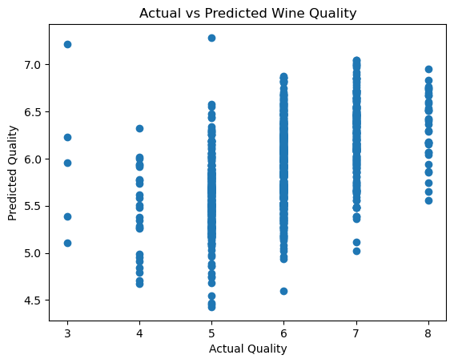

```python
plt.scatter(y_test, y_pred)
plt.xlabel('Actual Quality')
plt.ylabel('Predicted Quality')
plt.title('Actual vs Predicted Wine Quality')
plt.show()
```

```python
target_variable = 'quality'
X = df.drop(target_variable, axis=1)
y = df[target_variable]

X_train, X_test, y_train, y_test = train_test_split(X, y, test_size=0.2, random_state=42)

linear_reg_model = LinearRegression()
linear_reg_model.fit(X_train, y_train)

y_pred_linear = linear_reg_model.predict(X_test)

mse_linear = mean_squared_error(y_test, y_pred_linear)
print(f'Linear Regression Mean Squared Error: {mse_linear}')
```

```
Linear Regression Mean Squared Error: 0.5690247717275313
```

```python
random_forest_model = RandomForestRegressor()
random_forest_model.fit(X_train, y_train)

y_pred_rf = random_forest_model.predict(X_test)

mse_rf = mean_squared_error(y_test, y_pred_rf)
print(f'Random Forest Regressor Mean Squared Error: {mse_rf}')
```

```
Random Forest Regressor Mean Squared Error: 0.34733408163265306
```

B. Classification

```python
X = df.drop('quality', axis=1)
y = df['quality']

# default is 75% / 25% train-test split
X_train, X_test, y_train, y_test = train_test_split(X, y, random_state=0)

# Create a KNN classifier
knn = KNeighborsClassifier(n_neighbors = 5)

# Train the model
knn.fit(X_train, y_train)

# Train and test accuracy score
print('Accuracy of K-NN classifier on training set: {:.4f}'
     .format(knn.score(X_train, y_train)))
print('Accuracy of K-NN classifier on training set: {:.4f}'
     .format(knn.score(X_test, y_test)))
```

```
Accuracy of K-NN classifier on training set: 0.6515
Accuracy of K-NN classifier on training set: 0.4596
```

```python
y_pred_knn = knn.predict(X_test)

# Classification Report
print('Classification Report:')
print(classification_report(y_test, y_pred_knn))
```

```
Classification Report:
              precision    recall  f1-score   support

           3       0.00      0.00      0.00         9
           4       0.26      0.09      0.13        57
           5       0.43      0.45      0.44       375
           6       0.50      0.62      0.55       522
           7       0.42      0.27      0.33       223
           8       0.35      0.15      0.21        39

    accuracy                           0.46      1225
   macro avg       0.33      0.26      0.28      1225
weighted avg       0.44      0.46      0.44      1225
```

C. Optimisation

Optimizing hyperparameters is crucial for improving the performance of machine learning models. In the context of k-Nearest Neighbors (KNN) classification, the key hyperparameter is usually the number of neighbors (n_neighbors).

```python
# Define a range of values for the number of neighbors
param_grid = {'n_neighbors': [4, 3, 5, 7, 9]}

# Create a KNN classifier
knn_model = KNeighborsClassifier()

# Create a GridSearchCV object
grid_search = GridSearchCV(knn_model, param_grid, cv=5, scoring='accuracy')

# Fit the GridSearchCV object to the data
grid_search.fit(X_train, y_train)

# Get the best hyperparameters
best_params = grid_search.best_params_
print(f'Best Hyperparameters: {best_params}')

# Use the best model
best_knn_model = grid_search.best_estimator_

# Make predictions with the best model
y_pred_best = best_knn_model.predict(X_test)

# Evaluate the best model
accuracy_best = accuracy_score(y_test, y_pred_best)
print(f'Accuracy with Best Model: {accuracy_best}')
```

```
Best Hyperparameters: {'n_neighbors': 4}
Accuracy with Best Model: 0.4775510204081633
```

D. Improvements

Features : Try out feature engineering methods to either create meaningful features or modify existing ones. This process should involves transforming your data to make it more informative for the machine learning model.

More Data: In specific situations, especially when working with neural networks, consider applying data augmentation. This technique involves generating additional training samples by making small modifications to the existing data, helping the model generalize better.

Collaborative Learning: Experiment with collaborative learning, which involves combining the strengths of different algorithms. Ensemble learning, where predictions from multiple models are combined, is an example. This approach could lead to improved results by leveraging diverse perspectives from various models.

# 3. Visualisation:

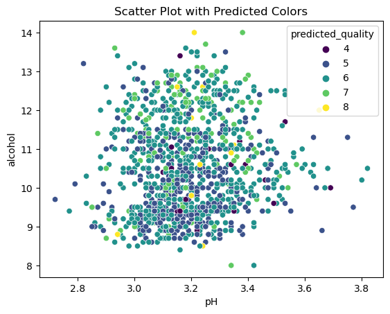

```python
# Assume 'quality' is the predicted class
df_visualization = X_test.copy()
df_visualization['predicted_quality'] = y_pred_knn

# Plotting
sns.scatterplot(x='pH', y='alcohol', hue='predicted_quality', data=df_visualization, palette='viridis')
plt.title('Scatter Plot with Predicted Colors')
plt.show()
```

[figure not shown]

```python
import seaborn as sns
from sklearn.metrics import confusion_matrix

# Calculate the confusion matrix
conf_matrix = confusion_matrix(y_test, y_pred_knn)

# Plotting the heatmap
sns.heatmap(conf_matrix, annot=True, fmt='d', cmap='Blues', xticklabels=['Class 0', 'Class 1'], yticklabels=['Class 0', 'Class 1'])
plt.title('Confusion Matrix Heatmap')
plt.xlabel('Predicted')
plt.ylabel('True')
plt.show()
```

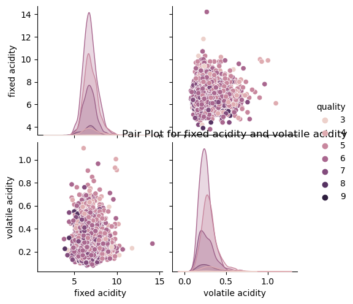

```python
import seaborn as sns
from sklearn.model_selection import train_test_split
from sklearn.neighbors import KNeighborsClassifier

# Assuming X and y are your dataset
# Split the dataset
X_train, X_test, y_train, y_test = train_test_split(X, y, test_size=0.2, random_state=42)

# Create a KNN classifier (replace this with your KNN classifier)
knn_classifier = KNeighborsClassifier(n_neighbors=5)
knn_classifier.fit(X_train, y_train)

# Choose two features for visualization (replace 'feature1' and 'feature2' with your feature names)
feature1 = 'fixed acidity'
feature2 = 'volatile acidity'

# Create a pair plot
sns.pairplot(df[[feature1, feature2, 'quality']], hue='quality', markers='o')
plt.title(f'Pair Plot for {feature1} and {feature2}')
plt.show()
```

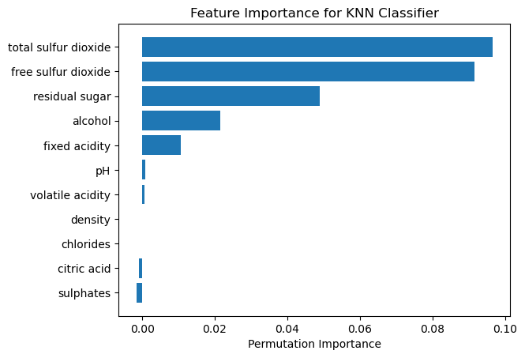

```python
# Calculate feature importance
result = permutation_importance(knn_classifier, X_test, y_test, n_repeats=10, random_state=42, n_jobs=-1)

# Sort feature importance
sorted_idx = result.importances_mean.argsort()

# Plot feature importance
plt.barh(range(X_test.shape[1]), result.importances_mean[sorted_idx])
plt.yticks(range(X_test.shape[1]), X_test.columns[sorted_idx])
plt.xlabel('Permutation Importance')
plt.title('Feature Importance for KNN Classifier')
plt.show()
```

# 4. Theoretical details:

Mathematical Formalism: Given a dataset with features X and corresponding labels y, the KNN algorithm classifies a new data point by considering the majority class among its k nearest neighbors.

Distance Metric:

Suppose you have two points in space. To figure out how far they are from each other, you use something called the Euclidean distance. It's like the straight-line distance between two points. The formula is a bit like the Pythagorean theorem you learned in school.

```
P=(p1,p2,...,pn)    Q=(q1,q2,...,qn)

          D(P,Q) = ∑(n,i=1) √(pi-qi)²
```

Nearest Neighbors:

Given a new data point, the k nearest neighbors are found based on the chosen distance metric.

Majority Vote:

The class label of the new data point is determined by a majority vote among its k nearest neighbors. The class with the highest count becomes the predicted class.

Parameters and Their Impact:

k: Number of Neighbors:

The parameter k determines the number of neighbors to consider when making predictions. Smaller values of k lead to more flexible models but may be sensitive to noise. Larger values of k result in smoother decision boundaries but may lead to underfitting.

Weighting Scheme:

Some implementations of KNN allow for a weighting scheme where closer neighbors have a higher influence on the prediction. For example, you might weigh neighbors inversely proportional to their distance.

Distance Metric:

The choice of distance metric (Euclidean, Manhattan, etc.) impacts how distances between data points are calculated. The appropriate distance metric depends on the nature of the data and the problem.

Feature Scaling:

The impact of features on distance calculations depends on their scales. It's often beneficial to scale features to ensure that no single feature dominates the distance metric.

Best Results: The "best" results depend on the specific characteristics of the dataset and the problem at hand. Some considerations include:

. Optimal

k: Choose the k that balances bias and variance for your dataset through techniques like cross-validation.

. Distance Metric: Experiment with different distance metrics based on the nature of the data. Euclidean distance is a common default, but it might not always be the most suitable.

. Feature Scaling: Evaluate the impact of feature scaling, especially if features have different scales.

. Weighting Scheme: Depending on the problem, you might experiment with different weighting schemes, such as uniform or distance-based weights.